# Mites distribution in apple orchard, and the effect of predatory mites, as biological control

## load libraries

```r
library("tidyverse")
library("plyr")
library("dplyr")
library("ggplot2")
#library("scales")
#library("ggpubr")
#library("gridExtra")
#library("grid")
#library("GGally")
library("data.table")
library("stringr")
library("janitor")
library("knitr")
library("kableExtra")
knitr::opts_chunk$set(echo = TRUE, warning = FALSE, message = FALSE)
                 #    fig.width = 20,
                  #    fig.asp = 0.6,
                   #   out.width = "100%")
```

The aim of the study is to look at the distribution of herbivore mites:  
- [*Tetranychus sp.*](https://www.biobee.com/pests/two-spotted-spider-mite/) (Yellow/red mite)  
- [*Panonychus ulmi*](http://www.agri.huji.ac.il/mepests/pest/Panonychus_ulmi/) (European red mite)  
- [*Bryobia rubrioculus*](http://www.agri.huji.ac.il/mepests/pest/Bryobia_rubrioculus/) (brwon mite)

and the predatory mites:  
- [*Typhlodromus athiasae*](http://www.agri.huji.ac.il/mepests/enemy/Typhlodromus_athiasae/) (local species)  
- [*Neoseiulus californicus*](https://entnemdept.ufl.edu/creatures/beneficial/neoseiulus_californicus.htm) (artificially introduced 30 years ago, and augmented in the current study).

- **High**: one sachet per tree, 8 rows.
- **Low**: one sachet every 5 trees, 7 rows.
- **Control**: no sachets applied, 7 rows.

**The study design was as follow:**  
A total of ~9 dunams, containing 22 rows, in each row one type of cultivar: Gala, Gold, Pink or Grani Smith.

In each row, 68 trees, except for Smith, which is planted in higher gaps and so 48 trees are planted per row.

```r
map <- read.csv(check.names=FALSE, "/Users/nuriteliash/Documents/GitHub/Biological-control-mites-apples/data/study_map.csv")
kable(map, caption = "Study design, each column is one row") %>%
  column_spec(1:23,border_left = T, border_right = T) %>%
kable_styling()
```

Study design, each column is one row

| row number | 22 | 21 | 20 | 19 | 18 | 17 | 16 | 15 | 14 | 13 | 12 | 11 | 10 | 9 | 8 | 7 | 6 | 5 | 4 | 3 | 2 | 1 |
| --- | --- | --- | --- | --- | --- | --- | --- | --- | --- | --- | --- | --- | --- | --- | --- | --- | --- | --- | --- | --- | --- | --- |
| treatment | low | control | high | low | control | high | low | control | high | control | high | low | high | low | control | low | high | control | low | high | control | high |
| apple strain | pink | pink | gala | gold | gold | smith | smith | smith | gala | pink | pink | gala | gold | gold | smith | smith | smith | gala | pink | pink | gala | gold |

the mites population was monitored every ~2 weeks, by inspecting 10 leaves under a magnified glass, and observing adult and eggs (5 outer and 5 inner leaves).

the level of infestation was classified as follow:  
- **“0”**: no mites observed  
- **“1-5”**  
- **“5-10”**  
- **10+“**, more then 10 mites/eggs per leave

5-8 trees were monitored per row, and the trees were marked and re-inspected each time.

| *The study was conducted in collaboration of [Shamir Research Institute](http://www.sri.org.il/Home), and [Biobee company](https://www.biobee.com/).* |
| --- |

### load data

```r
meta <- read.csv("/Users/nuriteliash/Documents/GitHub/Biological-control-mites-apples/data/18jun.csv")
design <- read.csv("/Users/nuriteliash/Documents/GitHub/Biological-control-mites-apples/data/design.csv")

data <- left_join(design,meta, by = "row") %>% # match the cultivar name to each row
  filter(row !="23") %>% # remove row 23 (we checked only once)
  mutate(across(everything(), as.character))

 data[data == ""] <- NA
 data[is.na(data)] <- 0

 #write the arranged data as csv file
#write_csv(x= data, file="/Users/nuriteliash/Documents/GitHub/Biological-control-mites-apples/outfiles/data.csv")

#data <- left_join(design,meta, by = "row") %>% # match the cultivar name to each row
 # filter(row !="23")
 #data <- data %>% mutate(across(-1,  ~ as.numeric(replace(., . == '', 0))))  %>%
#  mutate(across(everything(), as.character)) %>%
#replace(is.na(.),0)
```

## Adult mites distribution on leaves

### on outer leaves

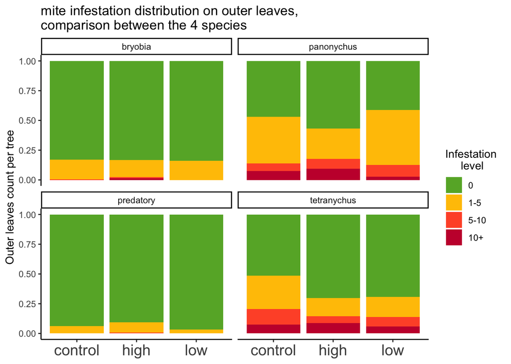

```r
# count adult mites
#on 5 outer leaves:
out_leaves <- data %>%
  dplyr::select(-contains('egg')) %>%
  dplyr::select(-starts_with('inner')) %>%
  pivot_longer(cols = starts_with('outer')) %>%
  separate(name, c('leave_position', 'leave_number', 'mite_species'))  %>%
  group_by( mite_species, tree, strain, treatment) %>%
  dplyr::count(value, .drop = FALSE)

# plot the distribution
out_leaves$value <- factor(out_leaves$value, levels = c("0","1-5","5-10","10+"))

out_leaves %>%
  ggplot(aes(fill=value, y=n, x=treatment)) +
    geom_bar(position="fill", stat="identity") +
    xlab("Treatment") +
    ylab("Outer leaves count per tree") +
    labs(title = "mite infestation distribution on outer leaves,
comparison between the 4 species") +
    labs(fill = "Infestation
     level") +
  theme_classic() +
  theme(axis.text.x = element_text(size=15),
        axis.title.x = element_blank()) + scale_fill_manual(values=c("#66b032", "#FFC300","#FF5733","#C70039")) +
  facet_wrap(~mite_species)
```

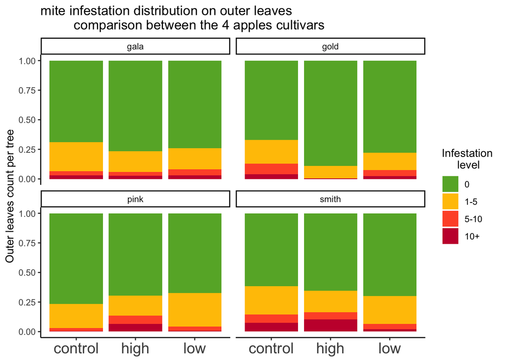

```r
out_leaves %>%
  ggplot(aes(fill=value, y=n, x=treatment)) +
    geom_bar(position="fill", stat="identity") +
    xlab("Treatment") +
    ylab("Outer leaves count per tree") +
    labs(title = "mite infestation distribution on outer leaves
         comparison between the 4 apples cultivars") +
    labs(fill = "Infestation
     level") +
  theme_classic() +
  theme(axis.text.x = element_text(size=15),
        axis.title.x = element_blank()) + scale_fill_manual(values=c("#66b032", "#FFC300","#FF5733","#C70039")) +
  facet_wrap(~strain)
```

### on Inner leaves

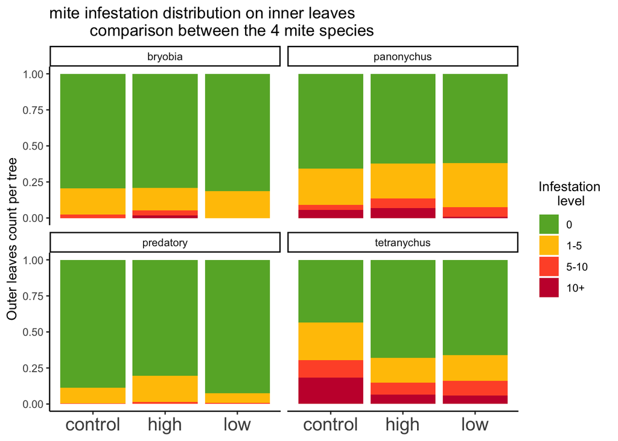

```r
# count adult mites
#on 5 outer leaves:
in_leaves <- data %>%
  dplyr::select(-contains('egg')) %>%
  dplyr::select(-starts_with('outer')) %>%
  pivot_longer(cols = starts_with('inner')) %>%
  separate(name, c('leave_position', 'leave_number', 'mite_species'))  %>%
  group_by( mite_species, tree, strain, treatment) %>%
  dplyr::count(value, .drop = FALSE)

# plot the distribution
in_leaves$value <- factor(in_leaves$value, levels = c("0","1-5","5-10","10+"))

in_leaves %>%
  ggplot(aes(fill=value, y=n, x=treatment)) +
    geom_bar(position="fill", stat="identity") +
    xlab("Treatment") +
    ylab("Outer leaves count per tree") +
    labs(title = "mite infestation distribution on inner leaves
         comparison between the 4 mite species") +
    labs(fill = "Infestation
     level") +
  theme_classic() +
  theme(axis.text.x = element_text(size=15),
        axis.title.x = element_blank()) + scale_fill_manual(values=c("#66b032", "#FFC300","#FF5733","#C70039")) +
  facet_wrap(~mite_species)
```

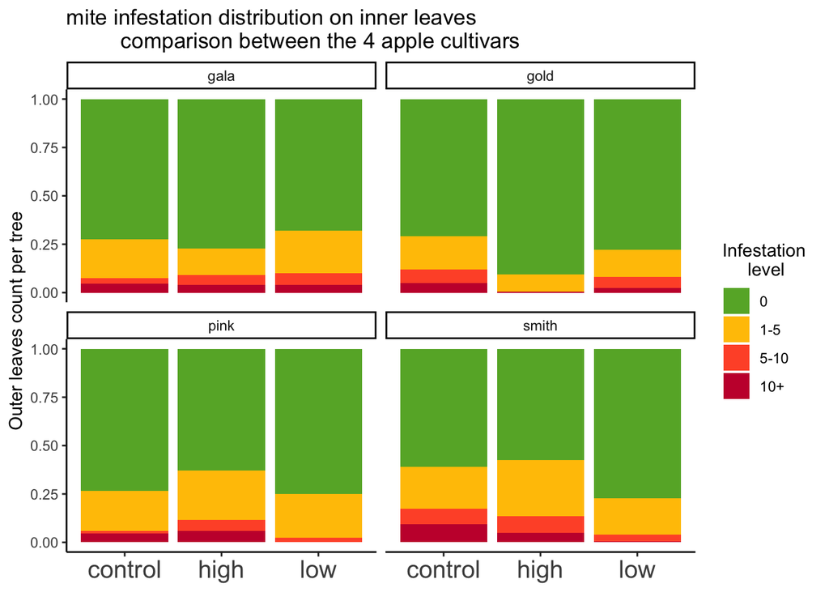

```r
in_leaves %>%
  ggplot(aes(fill=value, y=n, x=treatment)) +
    geom_bar(position="fill", stat="identity") +
    xlab("Treatment") +
    ylab("Outer leaves count per tree") +
    labs(title = "mite infestation distribution on inner leaves
         comparison between the 4 apple cultivars") +
    labs(fill = "Infestation
     level") +
  theme_classic() +
  theme(axis.text.x = element_text(size=15),
        axis.title.x = element_blank()) + scale_fill_manual(values=c("#66b032", "#FFC300","#FF5733","#C70039")) +
  facet_wrap(~strain)
```

## Mites’ eggs distribution on leaves

### on outer leaves

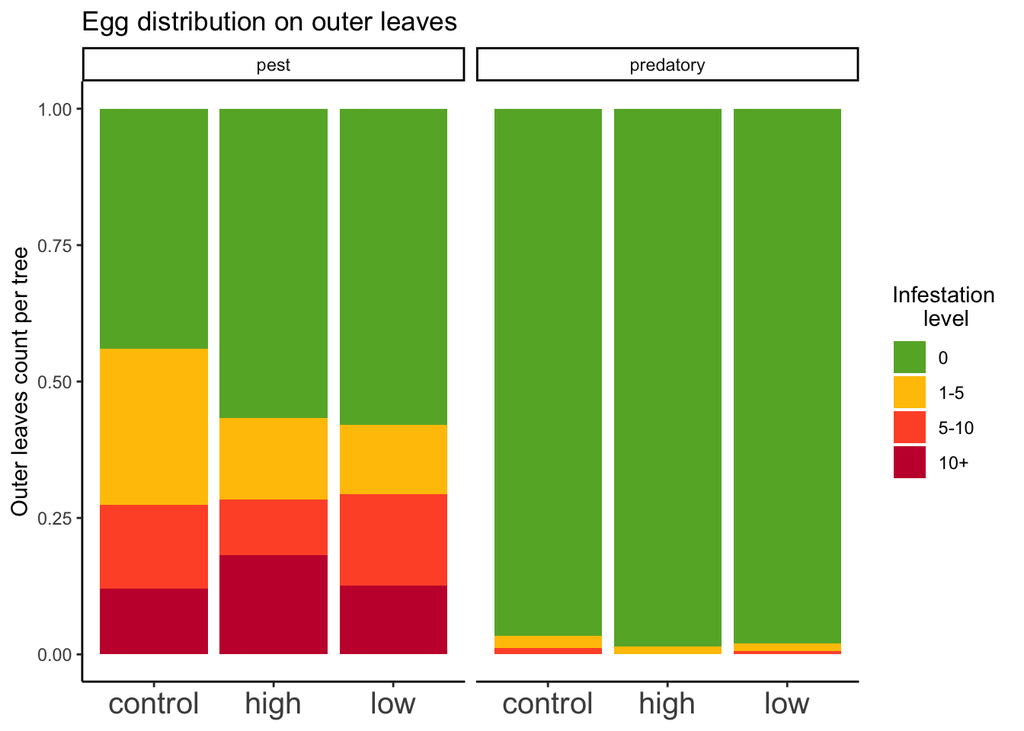

```r
# count  mites eggs on 5 outer leaves:
out_leaves_eggs <- data %>%
  dplyr::select( c(row, treatment, strain, tree),contains('Egg')) %>%
  dplyr::select(-starts_with('inner'))

# make a list of the columns to keep:
keep <- out_leaves_eggs %>% dplyr::select(starts_with('outer')) %>%
  colnames()
out_leaves_eggs <- out_leaves_eggs %>%
  mutate_at(keep, as.character) %>%
  pivot_longer(cols = starts_with('outer')) %>%
  separate(name, c('leave_position', 'leave_number', 'egg_type'))  %>%
  group_by(egg_type, tree, strain, treatment) %>%
  dplyr::count(value, .drop = FALSE)

# plot the distribution
out_leaves_eggs$value <- factor(out_leaves_eggs$value, levels = c("0","1-5","5-10","10+"))

out_leaves_eggs %>%
  ggplot(aes(fill=value, y=n, x=treatment)) +
    geom_bar(position="fill", stat="identity") +
    xlab("Treatment") +
    ylab("Outer leaves count per tree") +
    labs(title = "Egg distribution on outer leaves") +
    labs(fill = "Infestation
     level") +
  theme_classic() +
  theme(axis.text.x = element_text(size=15),
        axis.title.x = element_blank()) + scale_fill_manual(values=c("#66b032", "#FFC300","#FF5733","#C70039")) +
  facet_wrap(~egg_type)
```

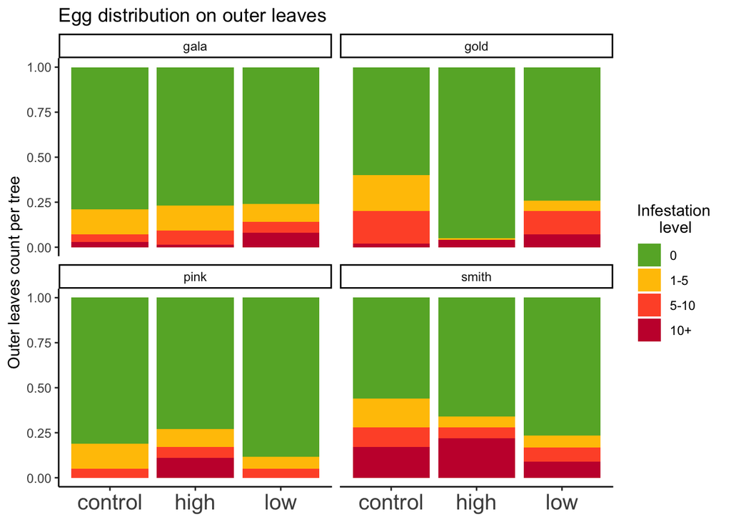

```r
out_leaves_eggs %>%
  ggplot(aes(fill=value, y=n, x=treatment)) +
    geom_bar(position="fill", stat="identity") +
    xlab("Treatment") +
    ylab("Outer leaves count per tree") +
    labs(title = "Egg distribution on outer leaves") +
    labs(fill = "Infestation
     level") +
  theme_classic() +
  theme(axis.text.x = element_text(size=15),
        axis.title.x = element_blank()) + scale_fill_manual(values=c("#66b032", "#FFC300","#FF5733","#C70039")) +
  facet_wrap(~strain)
```

### on inner leaves

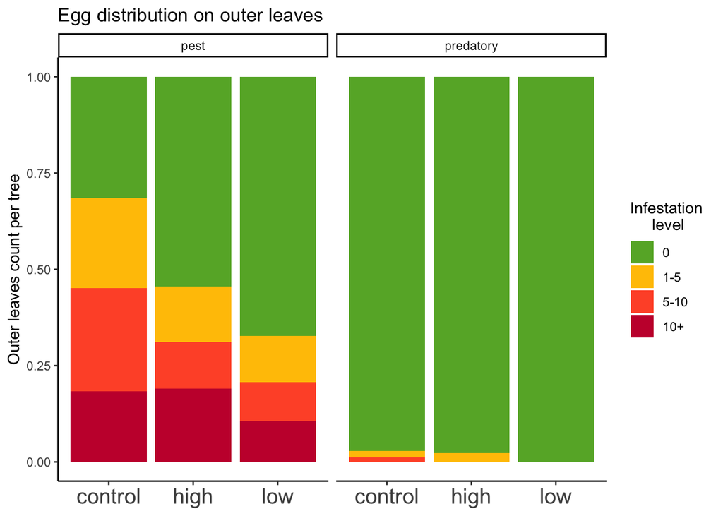

```r
# count  mites eggs
#on 5 inner leaves:
in_leaves_eggs <- data %>%
  dplyr::select( c(row, treatment, strain, tree),contains('egg')) %>%
  dplyr::select(-starts_with('outer')) %>%
  pivot_longer(cols = starts_with('inner')) %>%
  separate(name, c('leave_position', 'leave_number', 'egg_type'))  %>%
  group_by(egg_type, tree, strain, treatment) %>%
  dplyr::count(value, .drop = FALSE)

# plot the distribution
in_leaves_eggs$value <- factor(in_leaves_eggs$value, levels = c("0","1-5","5-10","10+"))

in_leaves_eggs %>%
  ggplot(aes(fill=value, y=n, x=treatment)) +
    geom_bar(position="fill", stat="identity") +
    xlab("Treatment") +
    ylab("Outer leaves count per tree") +
    labs(title = "Egg distribution on outer leaves") +
    labs(fill = "Infestation
     level") +
  theme_classic() +
  theme(axis.text.x = element_text(size=15),
        axis.title.x = element_blank()) + scale_fill_manual(values=c("#66b032", "#FFC300","#FF5733","#C70039")) +
  facet_wrap(~egg_type)
```

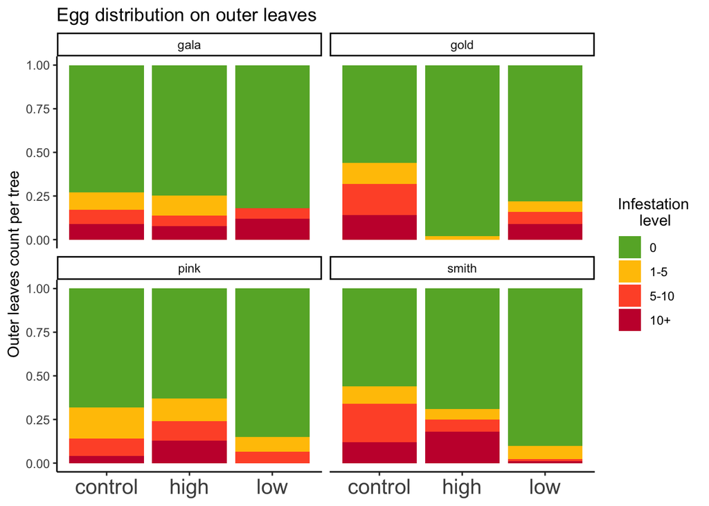

```r
in_leaves_eggs %>%
  ggplot(aes(fill=value, y=n, x=treatment)) +
    geom_bar(position="fill", stat="identity") +
    xlab("Treatment") +
    ylab("Outer leaves count per tree") +
    labs(title = "Egg distribution on outer leaves") +
    labs(fill = "Infestation
     level") +
  theme_classic() +
  theme(axis.text.x = element_text(size=15),
        axis.title.x = element_blank()) + scale_fill_manual(values=c("#66b032", "#FFC300","#FF5733","#C70039")) +
  facet_wrap(~strain)
```